# Heart Attack Analysis - CP and PDP explanations

## Task 1

Consider a following model:

f(x1, x2) = (x1 + x2)^2

Assume that x1, x2 ~ U[-1,1] and x1=x2 (full dependency)

Calculate PD profile for variable x1 in this model.

Extra task if you do not fear conditional expected values: Calculate ME and ALE profiles for variable x1 in this model.

## Task 2

For the selected dataset and models, prepare a knitr/jupyter notebook based on the following points (you can reuse models from previous Homeworks). Submit your results on GitHub to the directory `Homeworks/HW4`.

1. For the selected data set, train at least one tree-based ensemble model, e.g. random forest, gbdt, xgboost.
2. Calculate the predictions for some selected observations.
3. Then, calculate the what-if explanations of these predictions using Ceteris Paribus profiles (also called What-if plots), e.g. in Python: `AIX360`, `Alibi` `dalex`, `PDPbox`; in R: `pdp`, `DALEX`, `ALEplot`. **implement CP yourself for a potential bonus point*
4. Find two observations in the data set, such that they have different CP profiles. For example, model predictions are increasing with `age` for one observation and decreasing with `age` for another one. NOTE that you will need to have a model with interactions to observe such differences.
5. Compare CP, which is a local explanation, with PDP, which is a global explanation. **implement PDP yourself for a potential bonus point*
6. Compare PDP between between at least two different models.
7. ! COMMENT on the results obtained in (2)-(5)

## Task 1

$$f(x_1, x_2) = (x_1 + x_2)^2$$

### PD Profile

$$g^{j}_{PD}(z) = E_{x_2}(z + x_2)^2 = z^2 + 2E_{x_2}\left[ zx_2 \right] + E_{x_2} x_2^2 = z^2 + \int_{-1}^{1}\frac{1}{2}x^2\,dx = z^2 + \frac{1}{3}$$

# Task 2

For the selected data set, train at least one tree-based ensemble model, e.g. random forest, gbdt, xgboost. Calculate the predictions for some selected observations. Calculate the what-if explanations of these predictions using Ceteris Paribus profiles (also called What-if plots):

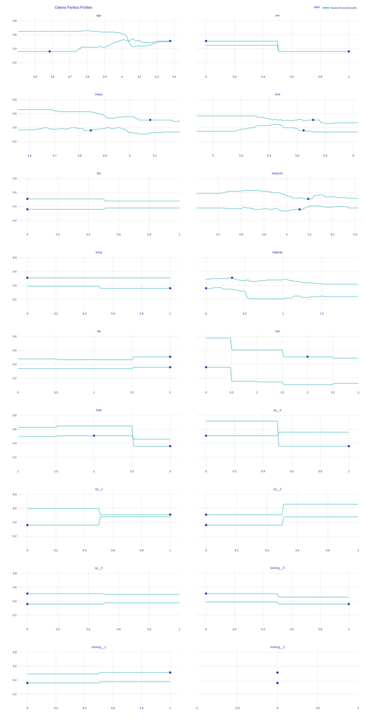

We see variables that conform to a couple of patterns:

- Clear monotonicity of the response variable wrt. these variables (`sex`, `cp__2`)
- Rougly no change/very small change of the response variable (`exng`, `fbs`)
- Unclear influence of the response variable (e.g. `chol`, `age`, `trtbps`) - here the response increases/decreases only in some particular interval of values

## 3. Find two observations in the data set, such that they have different CP profiles. For example, model predictions are increasing with age for one observation and decreasing with age for another one. NOTE that you will need to have a model with interactions to observe such differences.

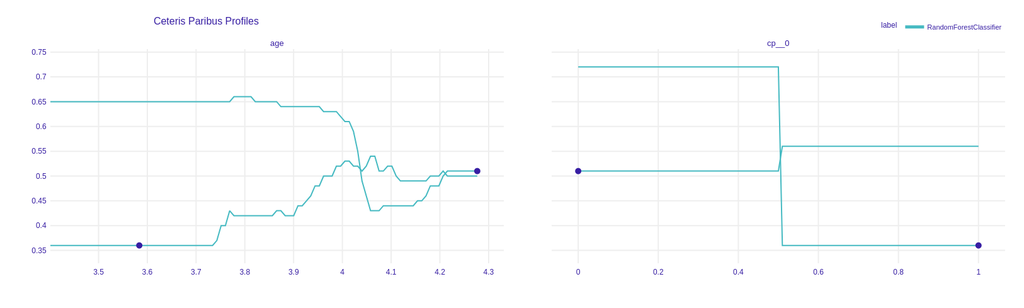

There are such variables for our already chosen pair of observations. We can see that in one of the cases response variable decreases with `age`, and in other observation it clearly increases. We have a similar effect also for the `cp__0` categorical variable.

## 4. Compare CP, which is a local explanation, with PDP, which is a global explanation.

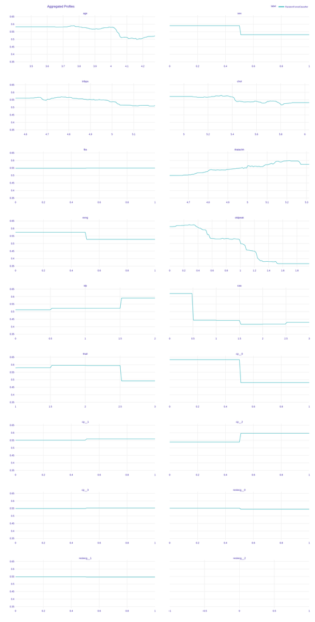

Comparing CP and PDP, trends are much more visible in PDP as it is averaged over much more examples. Now we can see the monotonicity of response wrt. variables like `age`, `oldpeak`, `thalachh`, `chol`.

For the `age` variable, we see that the PDP and CP plots for our first handpicked example are pretty similar. The same actually holds for `chol` and `trtbps`.

# 5. Compare PDP between between at least two different models.

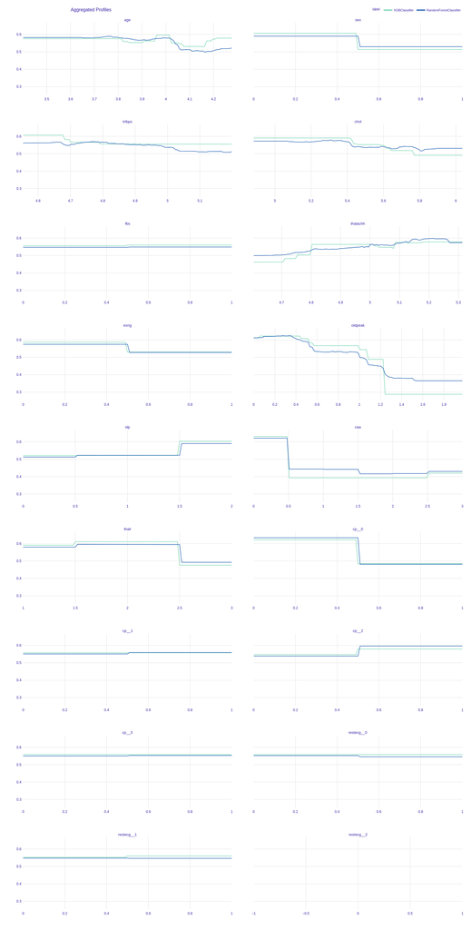

We compared two models: random forest and XGBoost - the models achieve similar metrics. The trends visible in the PDP plots are common for both models and most of the variables. There are a few exceptions:

- For the XGBoost model, the influence of the `age` variable is unclear, as the response fluctuates in some intervals, unlike the random forest model
- `oldpeak` variable seems to be more important for the XGBoost model
- For variables like `cp__1`, `cp__3` and `restecg__0`, they have zero influence in the XGBoost model and some minimal (but still) influence for the random forest model.

# Appendix

```python
# Download the dataset
!gdown --id 1NZWMlrVLLFcpeUxIUK8b5gG3DZ0qN3C2
!unzip heart_attack.zip
```

```python
!pip install dalex
```

```
     |████████████████████████████████| 1.0 MB 5.1 MB/s
```

```python
import pandas as pd
import numpy as np
import matplotlib.pyplot as plt
import seaborn as sns

from sklearn.model_selection import train_test_split

# models
from sklearn.linear_model import LogisticRegression
from sklearn.ensemble import RandomForestClassifier
from sklearn.tree import DecisionTreeClassifier

# metrics
from sklearn.metrics import precision_recall_fscore_support as score
from sklearn.metrics import confusion_matrix,accuracy_score
from sklearn.metrics import mean_squared_error,r2_score
from sklearn.metrics import plot_roc_curve
```

# Initial eyeballing over the data

We look at total number of examples (303) and also investigate balance of positive/negative class.

```python
ds = pd.read_csv('heart.csv')
print('Number of examples: ', len(ds))
ds.head()
```

```
Number of examples:  303
```

|  | age | sex | cp | trtbps | chol | fbs | restecg | thalachh | exng | oldpeak | slp | caa | thall | output |
| --- | --- | --- | --- | --- | --- | --- | --- | --- | --- | --- | --- | --- | --- | --- |
| 0 | 63 | 1 | 3 | 145 | 233 | 1 | 0 | 150 | 0 | 2.3 | 0 | 0 | 1 | 1 |
| 1 | 37 | 1 | 2 | 130 | 250 | 0 | 1 | 187 | 0 | 3.5 | 0 | 0 | 2 | 1 |
| 2 | 41 | 0 | 1 | 130 | 204 | 0 | 0 | 172 | 0 | 1.4 | 2 | 0 | 2 | 1 |
| 3 | 56 | 1 | 1 | 120 | 236 | 0 | 1 | 178 | 0 | 0.8 | 2 | 0 | 2 | 1 |
| 4 | 57 | 0 | 0 | 120 | 354 | 0 | 1 | 163 | 1 | 0.6 | 2 | 0 | 2 | 1 |

## Class balance

We can see that classes are pretty balanced so we don't have to apply any specific techniques for that

```python
ds.output.value_counts()
```

```
1    165
0    138
Name: output, dtype: int64
```

# Variables description

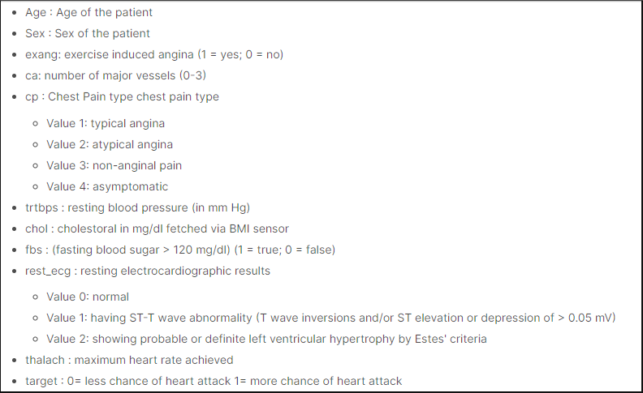

# Data preprocessing

We apply log transform to the numerical variables (so that they are more friendly for logistic regression-type models) and one-hot encoding for categorical variables.

```python
continuous_cols = ['age', 'chol','oldpeak', 'thalachh', 'trtbps']
categorical_cols = ['cp', 'restecg']

def categoricalize(df, columns):
    for col in columns:
        dummy_values = pd.get_dummies(df[col])
        for v in dummy_values.columns:
            df = pd.concat([df, dummy_values[v].rename(f'{col}__{v}')], axis=1)
    return df.drop(columns=columns)

processed_ds = categoricalize(ds, categorical_cols)

for col in continuous_cols:
    processed_ds[col] = np.log1p(ds[col])

x, y = processed_ds.drop(columns=['output']), processed_ds['output']

x_train, x_test, y_train, y_test=train_test_split(x, y,
                                               test_size=0.2,
                                               random_state=2139)


train_ds = x_train
test_ds = x_test
```

# Metrics

For the binary classification we measure the following metrics:

- Accuracy
- Precision
- Recall
- F1
- MSE

and also plot the confusion matrix

```python
def compute_metrics(y_pred, y_gt):
    cm=confusion_matrix(y_gt, y_pred)
    class_label = ["Low-risk", "High-risk"]
    df_cm = pd.DataFrame(cm, index=class_label,columns=class_label)
    sns.heatmap(df_cm,annot=True,cmap='Pastel1',linewidths=2,fmt='d')
    plt.title("Confusion Matrix",fontsize=15)
    plt.xlabel("predicted")
    plt.ylabel("actual")
    plt.show()

    acc=accuracy_score(y_gt,y_pred)
    mse=mean_squared_error(y_gt,y_pred)
    precision, recall, fscore, train_support = score(y_gt, y_pred, pos_label=1, average='binary')
    print('Precision: {} \nRecall: {} \nF1: {} \nAccuracy: {} %\nMSE: {}'.format(
        round(precision, 3), round(recall, 3), round(fscore,3), round((acc*100),3), round((mse),3)))

def train_and_evaluate_model(model):
    model.fit(train_ds, y_train)
    y_pred = model.predict(test_ds)

    compute_metrics(y_pred, y_test)
    plot_roc_curve(model, test_ds, y_test)
    return model
```

## 1. Calculate the predictions for some selected observations

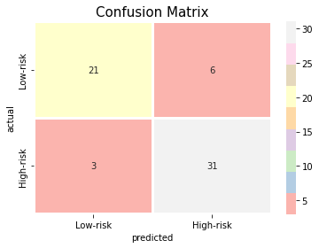

```
Precision: 0.838
Recall: 0.912
F1: 0.873
Accuracy: 85.246 %
MSE: 0.148
```

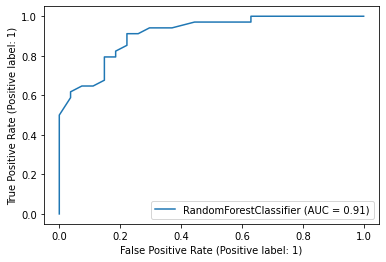

```python
# Fix the rng
np.random.seed(2137)

model = train_and_evaluate_model(RandomForestClassifier(random_state=69))
```

```python
chosen_indices = [0, 1]

test_subset, label = test_ds.iloc[chosen_indices], y_test.iloc[chosen_indices]
preds = model.predict_proba(test_subset)

preds
```

```
array([[0.49, 0.51],
       [0.64, 0.36]])
```

```python
label
```

```
25     1
239    0
Name: output, dtype: int64
```

We see that our two chosen examples have different labels, which might be important in further analysis.

## 2. Then, calculate the what-if explanations of these predictions using Ceteris Paribus profiles (also called What-if plots), e.g. in Python: AIX360, Alibi dalex, PDPbox; in R: pdp, DALEX, ALEplot. *implement CP yourself for a potential bonus point

```python
import dalex as dx

explainer = dx.Explainer(model, test_ds, y_test)
```

```
Preparation of a new explainer is initiated

  -> data              : 61 rows 18 cols
  -> target variable   : Parameter 'y' was a pandas.Series. Converted to a numpy.ndarray.
  -> target variable   : 61 values
  -> model_class       : sklearn.ensemble._forest.RandomForestClassifier (default)
  -> label             : Not specified, model's class short name will be used. (default)
  -> predict function  : <function yhat_proba_default at 0x7fa1d5c85a70> will be used (default)
  -> predict function  : Accepts pandas.DataFrame and numpy.ndarray.
  -> predicted values  : min = 0.0, mean = 0.549, max = 0.98
  -> model type        : classification will be used (default)
  -> residual function : difference between y and yhat (default)
  -> residuals         : min = -0.83, mean = 0.00852, max = 0.87
  -> model_info        : package sklearn

A new explainer has been created!
```

```python
cp = explainer.predict_profile(new_observation=test_subset)
cp.plot()
```

[interactive chart not shown]

We see variables that conform to a couple of patterns:

- Clear monotonicity of the response variable wrt. these variables (`sex`, `cp__2`)
- Rougly no change/very small change of the response variable (`exng`, `fbs`)
- Unclear influence of the response variable (e.g. `chol`, `age`, `trtbps`) - here the response increases/decreases only in some particular interval of values

## 3. Find two observations in the data set, such that they have different CP profiles. For example, model predictions are increasing with age for one observation and decreasing with age for another one. NOTE that you will need to have a model with interactions to observe such differences.

```python
cp.plot(variables=['age', 'cp__0'])
```

[interactive chart not shown]

There are such variables for our already chosen pair of observations. We can see that in one of the cases response variable decreases with `age`, and in other observation it clearly increases. We have a similar effect also for the `cp__0` categorical variable.

## 4. Compare CP, which is a local explanation, with PDP, which is a global explanation.

```python
pdp = explainer.model_profile()
```

```python
pdp.plot()
```

[interactive chart not shown]

Comparing CP and PDP, trends are much more visible in PDP as it is averaged over much more examples. Now we can see the monotonicity of response wrt. variables like `age`, `oldpeak`, `thalachh`, `chol`.

For the `age` variable, we see that the PDP and CP plots for our first handpicked example are pretty similar. The same actually holds for `chol` and `trtbps`.

# 5. Compare PDP between between at least two different models.

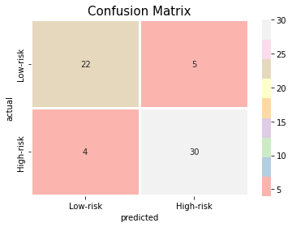

```
Precision: 0.857
Recall: 0.882
F1: 0.87
Accuracy: 85.246 %
MSE: 0.148
```

```
Preparation of a new explainer is initiated

  -> data              : 61 rows 18 cols
  -> target variable   : Parameter 'y' was a pandas.Series. Converted to a numpy.ndarray.
  -> target variable   : 61 values
  -> model_class       : xgboost.sklearn.XGBClassifier (default)
  -> label             : Not specified, model's class short name will be used. (default)
  -> predict function  : <function yhat_proba_default at 0x7fa1d5c85a70> will be used (default)
  -> predict function  : Accepts only pandas.DataFrame, numpy.ndarray causes problems.
  -> predicted values  : min = 0.00845, mean = 0.558, max = 0.987
  -> model type        : classification will be used (default)
  -> residual function : difference between y and yhat (default)
  -> residuals         : min = -0.874, mean = -0.000187, max = 0.977
  -> model_info        : package xgboost

A new explainer has been created!
```

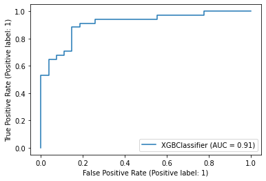

```python
from xgboost import XGBClassifier
xgb_model = train_and_evaluate_model(
    XGBClassifier(n_estimators=100, max_depth=2)
)
xgb_explainer = dx.Explainer(xgb_model, test_ds, y_test)
```

```python
xgb_pdp = xgb_explainer.model_profile()
xgb_pdp.plot(objects=pdp)
```

[interactive chart not shown]

We compared two models: random forest and XGBoost - the models achieve similar metrics. The trends visible in the PDP plots are common for both models and most of the variables. There are a few exceptions:

- For the XGBoost model, the influence of the `age` variable is unclear, as the response fluctuates in some intervals, unlike the random forest model
- `oldpeak` variable seems to be more important for the XGBoost model
- For variables like `cp__1`, `cp__3` and `restecg__0`, they have zero influence in the XGBoost model and some minimal (but still) influence for the random forest model.

```python
!jupyter nbconvert --to=html xai_hw4_st.ipynb
```

```
[NbConvertApp] Converting notebook xai_hw4_st.ipynb to html
[NbConvertApp] Writing 4106704 bytes to xai_hw4_st.html
```